# Projet_OCR

Author

Emilie CORDIER Damien LE BRIZOUAL Eudes ROSSIGNEUX

# 1 Introduction GLM analyse

Les abeilles sauvages (Hymenoptera : Apoidea) assurent une part essentielle de la pollinisation des plantes à fleurs (Ollerton, Winfree, and Tarrant 2011), pourtant 172 espèces européennes ont un statut “menacé”. Leur **taille corporelle** est un trait fonctionnel majeur : elle est corrélée à la distance de vol et donc à la capacité à exploiter des ressources dispersées dans le paysage (Greenleaf et al. 2007), et elle est généralement estimée par l’espace intertégulaire (Cane 1987).

L’urbanisation modifie profondément les ressources florales, les sites de nidification et la température locale (îlot de chaleur). Ces filtres environnementaux peuvent sélectionner des espèces, ou des individus, de taille différente (Banaszak-Cibicka and Żmihorski 2012; Cane et al. 2006; Hamblin et al. 2017). Les résultats sont toutefois contrastés : certaines études rapportent des bourdons plus petits en ville (Eggenberger et al. 2019), d’autres des individus plus grands dans les habitats fragmentés (Warzecha et al. 2016).

**Question de recherche :** *comment varie la taille des abeilles en fonction de leur genre, de leur sexe, de leur milieu de vie (contexte paysager) et de l’imperméabilisation du milieu ?*

La sélection de modèle repose sur le critère d’information d’Akaike (Akaike 1974; Burnham and Anderson 2002) ; les analyses sont réalisées avec R (R Core Team 2024).

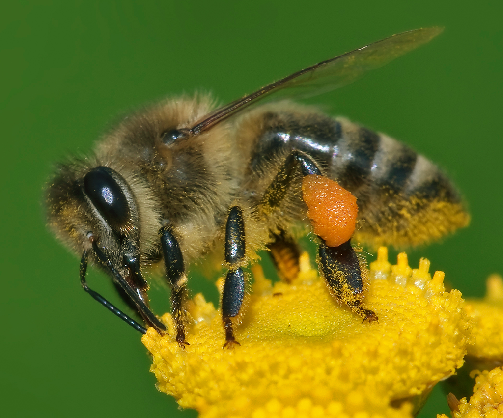

*Apis mellifera* butinant une fleur

# 2 Données et variables

Le tableau de données utilisé est issu de 4 tableaux publiés dans des journaux relus par des pairs. Les expériences ont toutes été réalisées en Ile-de-France. Néanmoins, un grand nombre de paramètres (milieu, matériel, nombre de sites, années, périodes de l’année échantillonnée, temps d’échantillonnage) diffèrent selon les expériences. B. et T. Geslin Benoît et Gauzens (2013) ont réalisés l’expérience dans 12 sites répartis dans quatre milieux différents (3 urbains, 3 sub-urbains, 3 agricoles et 3 semi-naturels) entre avril et juillet 2011 avec des coupelles. Ropars (2019) a réalisé l’expérience uniquement dans Paris, dans 5 sites différents en 2014 puis 7 en 2015 et 2016, entre mai et juillet en 2014 et avril et juillet en 2015 et 2016 avec des coupelles et des filets. A. et B. Zaninotto Vincent et Perrard (2021) ont réalisés une expérience à Paris et en milieux semi-naturels entre mars et octobre en 2017 et 2018 en capturant les abeilles directement sur 20 fleurs en pots (*Lotus corniculatus L.* et *Sinapsis alba*). Une autre expérience a été réalisé uniquement à Paris dans 12 sites différents entre mars et octobre en 2019 et 2020 avec des coupelles et des filets. I. Zaninotto Vincent et Dajoz (2022) ont réalisés des mesures de distances intertégulaires (i.e. largeur des abeilles, ITD) dans cette deuxième expérience pour chaque groupe d’espèces et par sexe. Cette distance est expérimée en millimètres. Le jeu de données (`Data_abeilles.txt`) contient un spécimen par ligne.

**Tableau de présentation des variables**

[output not shown]

> **Note :** la colonne 8 a été retirée dans le script (`Abeilles[,-8]`). Elle correspondait à la mesure de la distance intertégulaire et ne comprenait que des NA donc était inutilisable.

# 3 Analyses

## 3.1 Import et nettoyage

On importe le fichier (séparateur décimal `,`, chaînes converties en facteurs), on retire la colonne 8, puis les lignes comportant des valeurs manquantes. Les modèles sont ainsi tous ajustés sur le **même jeu de 271 observations**, condition indispensable pour comparer les AIC.

```r
Abeilles <- read.table("Data_abeilles.txt", header = TRUE, dec = ",",
                       stringsAsFactors = TRUE)
Abeilles <- Abeilles[, -8]
Abeilles_clean <- na.omit(Abeilles)

# Niveaux de référence (intercept) et effectifs
levels(Abeilles_clean$genre)
```

```
 [1] "Andrena"      "Apis"         "Bombus"       "Colletes"     "Dasypoda"
 [6] "Halictus"     "Hyaleus"      "Hylaeus"      "Lasioglossum" "Nomada"
[11] "Panurgus"     "Tetralonia"   "Xylocopa"
```

```r
levels(Abeilles_clean$contexte_paysager)
```

```
[1] "agricole" "seminat"  "suburb"   "urbain"
```

```r
table(Abeilles_clean$genre)
```

```
     Andrena         Apis       Bombus     Colletes     Dasypoda     Halictus
         101            8           49            0            0           81
     Hyaleus      Hylaeus Lasioglossum       Nomada     Panurgus   Tetralonia
           3           19            1            5            3            0
    Xylocopa
           1
```

## 3.2 Modèles linéaires emboîtés

On construit progressivement des modèles linéaires, en ajoutant une variable explicative à chaque étape.

```r
# mod1 : genre seul
mod1 <- lm(TailleR ~ genre, data = Abeilles_clean)
summary(mod1)
```

```
Call:
lm(formula = TailleR ~ genre, data = Abeilles_clean)

Residuals:
    Min      1Q  Median      3Q     Max
-0.9253 -0.3960  0.0000  0.2248  0.9948

Coefficients:
                  Estimate Std. Error t value Pr(>|t|)
(Intercept)        1.95525    0.04040  48.397  < 2e-16 ***
genreApis          0.94475    0.14913   6.335 1.03e-09 ***
genreBombus        1.79720    0.07069  25.425  < 2e-16 ***
genreHalictus     -0.07846    0.06056  -1.296 0.196272
genreHyaleus      -0.87525    0.23787  -3.680 0.000284 ***
genreHylaeus      -0.79841    0.10153  -7.864 9.87e-14 ***
genreLasioglossum -0.79525    0.40802  -1.949 0.052363 .
genreNomada       -0.54925    0.18602  -2.953 0.003437 **
genrePanurgus     -0.37525    0.23787  -1.578 0.115884
genreXylocopa      3.75475    0.40802   9.202  < 2e-16 ***
---
Signif. codes:  0 '***' 0.001 '**' 0.01 '*' 0.05 '.' 0.1 ' ' 1

Residual standard error: 0.406 on 261 degrees of freedom
Multiple R-squared:  0.8059,    Adjusted R-squared:  0.7992
F-statistic: 120.4 on 9 and 261 DF,  p-value: < 2.2e-16
```

```r
anova(mod1)
```

```
Analysis of Variance Table

Response: TailleR
           Df  Sum Sq Mean Sq F value    Pr(>F)
genre       9 178.606 19.8452  120.38 < 2.2e-16 ***
Residuals 261  43.026  0.1648
---
Signif. codes:  0 '***' 0.001 '**' 0.01 '*' 0.05 '.' 0.1 ' ' 1
```

Le genre seul explique déjà **80,6 %** de la variance (R² = 0,806) : la taille dépend avant tout de la taxonomie (*Xylocopa* et *Bombus* sont bien plus grands, *Lasioglossum* et *Hylaeus* plus petits).

```r
# mod2 : + sexe
mod2 <- lm(TailleR ~ genre + sexe, data = Abeilles_clean)
summary(mod2)
```

```
Call:
lm(formula = TailleR ~ genre + sexe, data = Abeilles_clean)

Residuals:
     Min       1Q   Median       3Q      Max
-0.76042 -0.31036  0.03958  0.15958  0.92958

Coefficients:
                  Estimate Std. Error t value Pr(>|t|)
(Intercept)        2.02042    0.04046  49.930  < 2e-16 ***
genreApis          0.87958    0.14266   6.166 2.67e-09 ***
genreBombus        1.74994    0.06796  25.748  < 2e-16 ***
genreHalictus     -0.14363    0.05904  -2.433   0.0157 *
genreHyaleus      -0.50161    0.23766  -2.111   0.0358 *
genreHylaeus      -0.63262    0.10181  -6.214 2.04e-09 ***
genreLasioglossum -0.86042    0.38904  -2.212   0.0279 *
genreNomada       -0.43889    0.17852  -2.459   0.0146 *
genrePanurgus     -0.14788    0.23081  -0.641   0.5223
genreXylocopa      3.68958    0.38904   9.484  < 2e-16 ***
sexem             -0.43881    0.08385  -5.233 3.43e-07 ***
---
Signif. codes:  0 '***' 0.001 '**' 0.01 '*' 0.05 '.' 0.1 ' ' 1

Residual standard error: 0.3869 on 260 degrees of freedom
Multiple R-squared:  0.8244,    Adjusted R-squared:  0.8176
F-statistic:   122 on 10 and 260 DF,  p-value: < 2.2e-16
```

```r
anova(mod2)
```

```
Analysis of Variance Table

Response: TailleR
           Df  Sum Sq Mean Sq F value    Pr(>F)
genre       9 178.606 19.8452 132.554 < 2.2e-16 ***
sexe        1   4.100  4.1002  27.387 3.434e-07 ***
Residuals 260  38.925  0.1497
---
Signif. codes:  0 '***' 0.001 '**' 0.01 '*' 0.05 '.' 0.1 ' ' 1
```

Les mâles sont en moyenne plus petits que les femelles (≈ −0,44 unité, p < 0,001) ; le R² passe à 0,824.

```r
# mod3 : + contexte paysager
mod3 <- lm(TailleR ~ genre + sexe + contexte_paysager, data = Abeilles_clean)
summary(mod3)
```

```
Call:
lm(formula = TailleR ~ genre + sexe + contexte_paysager, data = Abeilles_clean)

Residuals:
     Min       1Q   Median       3Q      Max
-0.86492 -0.28395 -0.02977  0.22873  1.13023

Coefficients:
                         Estimate Std. Error t value Pr(>|t|)
(Intercept)               2.23652    0.05379  41.580  < 2e-16 ***
genreApis                 0.97604    0.13445   7.259 4.62e-12 ***
genreBombus               1.59055    0.06637  23.965  < 2e-16 ***
genreHalictus            -0.24732    0.05712  -4.330 2.14e-05 ***
genreHyaleus             -0.41258    0.21829  -1.890  0.05988 .
genreHylaeus             -0.49073    0.09894  -4.960 1.28e-06 ***
genreLasioglossum        -1.07652    0.35779  -3.009  0.00288 **
genreNomada              -0.30920    0.16495  -1.874  0.06200 .
genrePanurgus            -0.20440    0.21158  -0.966  0.33493
genreXylocopa             3.39508    0.36115   9.401  < 2e-16 ***
sexem                    -0.32719    0.08122  -4.028 7.41e-05 ***
contexte_paysagerseminat -0.28525    0.05667  -5.034 9.05e-07 ***
contexte_paysagersuburb   0.07840    0.07481   1.048  0.29565
contexte_paysagerurbain  -0.41675    0.07336  -5.681 3.62e-08 ***
---
Signif. codes:  0 '***' 0.001 '**' 0.01 '*' 0.05 '.' 0.1 ' ' 1

Residual standard error: 0.3537 on 257 degrees of freedom
Multiple R-squared:  0.8549,    Adjusted R-squared:  0.8476
F-statistic: 116.5 on 13 and 257 DF,  p-value: < 2.2e-16
```

```r
anova(mod3)
```

```
Analysis of Variance Table

Response: TailleR
                   Df  Sum Sq Mean Sq F value    Pr(>F)
genre               9 178.606 19.8452 158.607 < 2.2e-16 ***
sexe                1   4.100  4.1002  32.770 2.885e-08 ***
contexte_paysager   3   6.769  2.2564  18.034 1.187e-10 ***
Residuals         257  32.156  0.1251
---
Signif. codes:  0 '***' 0.001 '**' 0.01 '*' 0.05 '.' 0.1 ' ' 1
```

Le contexte paysager apporte une information significative (p ≈ 10⁻¹⁰) : les abeilles sont plus petites en milieu urbain et semi-naturel qu’au niveau de référence ; le milieu *suburb* ne s’en distingue pas.

```r
# mod4 : + imperméabilisation (effet additif)
mod4 <- lm(TailleR ~ genre + sexe + contexte_paysager + Impermeabilisation500m,
           data = Abeilles_clean)
summary(mod4)
```

```
Call:
lm(formula = TailleR ~ genre + sexe + contexte_paysager + Impermeabilisation500m,
    data = Abeilles_clean)

Residuals:
     Min       1Q   Median       3Q      Max
-0.83225 -0.25971 -0.03574  0.20784  1.14108

Coefficients:
                          Estimate Std. Error t value Pr(>|t|)
(Intercept)               2.230407   0.054480  40.940  < 2e-16 ***
genreApis                 0.975375   0.134578   7.248 5.00e-12 ***
genreBombus               1.592870   0.066504  23.952  < 2e-16 ***
genreHalictus            -0.243381   0.057427  -4.238 3.15e-05 ***
genreHyaleus             -0.411976   0.218490  -1.886  0.06049 .
genreHylaeus             -0.492431   0.099056  -4.971 1.22e-06 ***
genreLasioglossum        -1.071085   0.358191  -2.990  0.00306 **
genreNomada              -0.315520   0.165323  -1.909  0.05744 .
genrePanurgus            -0.213721   0.212153  -1.007  0.31470
genreXylocopa             3.377077   0.362313   9.321  < 2e-16 ***
sexem                    -0.328679   0.081324  -4.042 7.03e-05 ***
contexte_paysagerseminat -0.307900   0.064592  -4.767 3.14e-06 ***
contexte_paysagersuburb   0.032307   0.097802   0.330  0.74142
contexte_paysagerurbain  -0.576736   0.230380  -2.503  0.01292 *
Impermeabilisation500m    0.001884   0.002572   0.733  0.46444
---
Signif. codes:  0 '***' 0.001 '**' 0.01 '*' 0.05 '.' 0.1 ' ' 1

Residual standard error: 0.354 on 256 degrees of freedom
Multiple R-squared:  0.8552,    Adjusted R-squared:  0.8473
F-statistic:   108 on 14 and 256 DF,  p-value: < 2.2e-16
```

```r
anova(mod4)
```

```
Analysis of Variance Table

Response: TailleR
                        Df  Sum Sq Mean Sq  F value    Pr(>F)
genre                    9 178.606 19.8452 158.3211 < 2.2e-16 ***
sexe                     1   4.100  4.1002  32.7109 2.974e-08 ***
contexte_paysager        3   6.769  2.2564  18.0013 1.246e-10 ***
Impermeabilisation500m   1   0.067  0.0673   0.5368    0.4644
Residuals              256  32.089  0.1253
---
Signif. codes:  0 '***' 0.001 '**' 0.01 '*' 0.05 '.' 0.1 ' ' 1
```

L’imperméabilisation n’apporte rien une fois le contexte paysager pris en compte (p = 0,46) : les deux variables sont fortement liées (le contexte est en quelque sorte une version catégorielle de l’imperméabilisation).

```r
# mod5 : interaction contexte x imperméabilisation
mod5 <- lm(TailleR ~ genre + sexe + contexte_paysager * Impermeabilisation500m,
           data = Abeilles_clean)
summary(mod5)
```

```
Call:
lm(formula = TailleR ~ genre + sexe + contexte_paysager * Impermeabilisation500m,
    data = Abeilles_clean)

Residuals:
     Min       1Q   Median       3Q      Max
-0.79723 -0.26252 -0.01673  0.21057  1.09875

Coefficients:
                                                 Estimate Std. Error t value
(Intercept)                                      2.256607   0.067574  33.394
genreApis                                        0.975189   0.136159   7.162
genreBombus                                      1.586696   0.067909  23.365
genreHalictus                                   -0.252708   0.058847  -4.294
genreHyaleus                                    -0.412298   0.219434  -1.879
genreHylaeus                                    -0.486522   0.100702  -4.831
genreLasioglossum                               -1.093680   0.361294  -3.027
genreNomada                                     -0.307496   0.167005  -1.841
genrePanurgus                                   -0.197634   0.213947  -0.924
genreXylocopa                                    3.346112   0.367136   9.114
sexem                                           -0.327892   0.081894  -4.004
contexte_paysagerseminat                        -0.321791   0.081311  -3.958
contexte_paysagersuburb                         -0.054360   0.150044  -0.362
contexte_paysagerurbain                          0.005393   1.405871   0.004
Impermeabilisation500m                          -0.008132   0.017176  -0.473
contexte_paysagerseminat:Impermeabilisation500m  0.009446   0.017460   0.541
contexte_paysagersuburb:Impermeabilisation500m   0.012471   0.017765   0.702
contexte_paysagerurbain:Impermeabilisation500m   0.003147   0.023123   0.136
                                                Pr(>|t|)
(Intercept)                                      < 2e-16 ***
genreApis                                       8.64e-12 ***
genreBombus                                      < 2e-16 ***
genreHalictus                                   2.50e-05 ***
genreHyaleus                                     0.06141 .
genreHylaeus                                    2.35e-06 ***
genreLasioglossum                                0.00272 **
genreNomada                                      0.06676 .
genrePanurgus                                    0.35650
genreXylocopa                                    < 2e-16 ***
sexem                                           8.19e-05 ***
contexte_paysagerseminat                        9.84e-05 ***
contexte_paysagersuburb                          0.71743
contexte_paysagerurbain                          0.99694
Impermeabilisation500m                           0.63629
contexte_paysagerseminat:Impermeabilisation500m  0.58898
contexte_paysagersuburb:Impermeabilisation500m   0.48333
contexte_paysagerurbain:Impermeabilisation500m   0.89185
---
Signif. codes:  0 '***' 0.001 '**' 0.01 '*' 0.05 '.' 0.1 ' ' 1

Residual standard error: 0.3556 on 253 degrees of freedom
Multiple R-squared:  0.8557,    Adjusted R-squared:  0.846
F-statistic: 88.24 on 17 and 253 DF,  p-value: < 2.2e-16
```

```r
anova(mod5)
```

```
Analysis of Variance Table

Response: TailleR
                                          Df  Sum Sq Mean Sq  F value    Pr(>F)
genre                                      9 178.606 19.8452 156.9704 < 2.2e-16
sexe                                       1   4.100  4.1002  32.4318 3.416e-08
contexte_paysager                          3   6.769  2.2564  17.8477 1.539e-10
Impermeabilisation500m                     1   0.067  0.0673   0.5322    0.4664
contexte_paysager:Impermeabilisation500m   3   0.103  0.0344   0.2720    0.8456
Residuals                                253  31.986  0.1264

genre                                    ***
sexe                                     ***
contexte_paysager                        ***
Impermeabilisation500m
contexte_paysager:Impermeabilisation500m
Residuals
---
Signif. codes:  0 '***' 0.001 '**' 0.01 '*' 0.05 '.' 0.1 ' ' 1
```

L’interaction n’est pas significative (p = 0,85) et déstabilise le modèle (erreur standard de 1,41 pour le contexte « urbain »), ce qui traduit une colinéarité et un manque de données.

## 3.3 Sélection de modèle par AIC (procédure *forward*)

Pour confirmer ces résultats, on applique une sélection ascendante : on part du modèle nul et on ajoute à chaque étape la variable qui **diminue le plus l’AIC**. On s’arrête quand aucun ajout ne l’améliore.

```r
# Étape 0 : modèle nul
mod0 <- lm(TailleR ~ 1, data = Abeilles_clean)
add1(mod0, ~ genre + sexe + lectisme + contexte_paysager + Impermeabilisation500m)
```

```
Single term additions

Model:
TailleR ~ 1
                       Df Sum of Sq     RSS     AIC
<none>                              221.632  -52.50
genre                   9   178.606  43.026 -478.73
sexe                    1    24.627 197.005  -82.42
lectisme                2     4.233 217.399  -53.72
contexte_paysager       3    58.345 163.287 -129.29
Impermeabilisation500m  1    25.195 196.437  -83.20
```

```r
# -> genre : AIC le plus bas (-478,7)

# Étape 1 : genre
mod_genre <- lm(TailleR ~ genre, data = Abeilles_clean)
add1(mod_genre, ~ genre + sexe + lectisme + contexte_paysager + Impermeabilisation500m)
```

```
Single term additions

Model:
TailleR ~ genre
                       Df Sum of Sq    RSS     AIC
<none>                              43.026 -478.73
sexe                    1    4.1002 38.925 -503.87
lectisme                1    0.0855 42.940 -477.27
contexte_paysager       3    8.8392 34.186 -535.05
Impermeabilisation500m  1    3.8103 39.215 -501.86
```

```r
# -> contexte_paysager : AIC le plus bas (-535,1)

# Étape 2 : genre + contexte
mod_gc <- lm(TailleR ~ genre + contexte_paysager, data = Abeilles_clean)
add1(mod_gc, ~ genre + sexe + lectisme + contexte_paysager + Impermeabilisation500m)
```

```
Single term additions

Model:
TailleR ~ genre + contexte_paysager
                       Df Sum of Sq    RSS     AIC
<none>                              34.186 -535.05
sexe                    1   2.03024 32.156 -549.64
lectisme                1   0.04680 34.140 -533.42
Impermeabilisation500m  1   0.05002 34.136 -533.44
```

```r
# -> sexe : AIC le plus bas (-549,6)

# Étape 3 : genre + contexte + sexe
mod_gcs <- lm(TailleR ~ genre + contexte_paysager + sexe, data = Abeilles_clean)
add1(mod_gcs, ~ genre + sexe + lectisme + contexte_paysager + Impermeabilisation500m)
```

```
Single term additions

Model:
TailleR ~ genre + contexte_paysager + sexe
                       Df Sum of Sq    RSS     AIC
<none>                              32.156 -549.64
lectisme                1  0.017862 32.138 -547.79
Impermeabilisation500m  1  0.067284 32.089 -548.21
```

```r
# -> aucun ajout ne fait baisser l'AIC (-547,8 et -548,2 > -549,6) : on s'arrête
```

Le modèle retenu est donc : **`TailleR ~ genre + contexte_paysager + sexe`**.

## 3.4 Modèle final

```r
summary(mod_gcs)
```

```
Call:
lm(formula = TailleR ~ genre + contexte_paysager + sexe, data = Abeilles_clean)

Residuals:
     Min       1Q   Median       3Q      Max
-0.86492 -0.28395 -0.02977  0.22873  1.13023

Coefficients:
                         Estimate Std. Error t value Pr(>|t|)
(Intercept)               2.23652    0.05379  41.580  < 2e-16 ***
genreApis                 0.97604    0.13445   7.259 4.62e-12 ***
genreBombus               1.59055    0.06637  23.965  < 2e-16 ***
genreHalictus            -0.24732    0.05712  -4.330 2.14e-05 ***
genreHyaleus             -0.41258    0.21829  -1.890  0.05988 .
genreHylaeus             -0.49073    0.09894  -4.960 1.28e-06 ***
genreLasioglossum        -1.07652    0.35779  -3.009  0.00288 **
genreNomada              -0.30920    0.16495  -1.874  0.06200 .
genrePanurgus            -0.20440    0.21158  -0.966  0.33493
genreXylocopa             3.39508    0.36115   9.401  < 2e-16 ***
contexte_paysagerseminat -0.28525    0.05667  -5.034 9.05e-07 ***
contexte_paysagersuburb   0.07840    0.07481   1.048  0.29565
contexte_paysagerurbain  -0.41675    0.07336  -5.681 3.62e-08 ***
sexem                    -0.32719    0.08122  -4.028 7.41e-05 ***
---
Signif. codes:  0 '***' 0.001 '**' 0.01 '*' 0.05 '.' 0.1 ' ' 1

Residual standard error: 0.3537 on 257 degrees of freedom
Multiple R-squared:  0.8549,    Adjusted R-squared:  0.8476
F-statistic: 116.5 on 13 and 257 DF,  p-value: < 2.2e-16
```

```r
anova(mod_gcs)
```

```
Analysis of Variance Table

Response: TailleR
                   Df  Sum Sq Mean Sq F value    Pr(>F)
genre               9 178.606 19.8452 158.607 < 2.2e-16 ***
contexte_paysager   3   8.839  2.9464  23.548 1.690e-13 ***
sexe                1   2.030  2.0302  16.226 7.406e-05 ***
Residuals         257  32.156  0.1251
---
Signif. codes:  0 '***' 0.001 '**' 0.01 '*' 0.05 '.' 0.1 ' ' 1
```

```r
mod_gcs$coefficients
```

```
             (Intercept)                genreApis              genreBombus
              2.23652205               0.97604077               1.59054977
           genreHalictus             genreHyaleus             genreHylaeus
             -0.24732058              -0.41258359              -0.49072529
       genreLasioglossum              genreNomada            genrePanurgus
             -1.07652205              -0.30919563              -0.20439511
           genreXylocopa contexte_paysagerseminat  contexte_paysagersuburb
              3.39507734              -0.28525434               0.07840061
 contexte_paysagerurbain                    sexem
             -0.41675043              -0.32718803
```

Le modèle explique **85,5 %** de la variance (R² ajusté = 0,848 ; erreur résiduelle = 0,354).

Équation de prédiction (par rapport aux niveaux de référence) :

$$\begin{aligned}
\widehat{\text{Taille}} ={}& 2{,}24 + 0{,}98\,\text{Apis} + 1{,}59\,\text{Bombus} - 0{,}25\,\text{Halictus} - 0{,}41\,\text{Hyaleus} \\
& - 0{,}49\,\text{Hylaeus} - 1{,}08\,\text{Lasioglossum} - 0{,}31\,\text{Nomada} - 0{,}20\,\text{Panurgus} + 3{,}40\,\text{Xylocopa} \\
& - 0{,}29\,\text{seminat} + 0{,}08\,\text{suburb} - 0{,}42\,\text{urbain} - 0{,}33\,\text{sexe}_m
\end{aligned}$$

Chaque variable catégorielle vaut 1 si le spécimen appartient à la modalité, 0 sinon. Exemple d’usage de la fonction `predict()` :

```r
# Exemple (adapter les niveaux à ceux de votre jeu de données)
nouveau <- data.frame(genre = "Bombus",
                      contexte_paysager = "urbain",
                      sexe = "m")
predict(mod_gcs, newdata = nouveau, interval = "prediction")
```

```
       fit      lwr      upr
1 3.083133 2.360225 3.806042
```

## 3.5 Vérification des conditions de validation du modèle

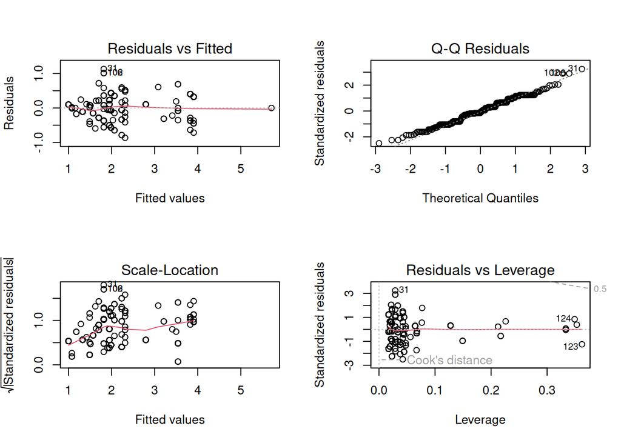

```r
par(mfrow = c(2, 2))
plot(mod_gcs)
```

```r
par(mfrow = c(1, 1))
```

**Commentaires sur les conditions de validation**

Pour les 4 graphiques:

- **Graphique des résidus en fonction des valeurs ajustées:** Bonne répartition des valeurs autour de 0
- **Diagramme Q-Q:** L’alignement global montre un respect de la normalité des résidus
- **Graphique Scale-Location:** Tendance croissante de la courbe de tendance - possible hétéroscédasticité (variance des résidus), point sensible
- **Graphique des résidus en fonction des leviers:** Aucun point n’exerce une influence trop importante (vérification tout de même de certains : 31, 123 et 124)

# 4 Discussion

**Le genre domine la variation de taille.** Il représente 80,6 % de la somme des carrés totale, contre 4,0 % pour le contexte paysager et 0,9 % pour le sexe (résiduelle : 14,5 %). C’est attendu : la taille est un trait fortement conservé phylogénétiquement, et les écarts entre genres (de *Lasioglossum* à *Xylocopa*) sont considérables (Michener 2007; Bartomeus et al. 2013). Cette variation interspécifique doit être contrôlée pour pouvoir détecter des effets environnementaux plus fins.

**Le sexe.** Les mâles sont plus petits que les femelles de 0,33 unité environ à genre et milieu égaux. Ce dimorphisme est courant chez les abeilles, et il justifie de toujours intégrer le sexe dans les analyses de taille.

**Le contexte paysager.** À genre et sexe égaux, les abeilles sont plus petites en milieu urbain (−0,42) et semi-naturel (−0,29) qu’au niveau de référence. Le sens de l’effet urbain concorde avec les bourdons plus petits observés en ville (Eggenberger et al. 2019) et avec l’hypothèse de l’îlot de chaleur : des températures plus élevées favorisent des individus plus petits, dont les limites thermiques diffèrent (Hamblin et al. 2017). Une autre explication tient à la ressource : les petites abeilles ont un rayon de vol réduit (Greenleaf et al. 2007) et sont moins pénalisées dans un paysage fragmenté où les fleurs sont proches mais rares ; à l’inverse, les grandes espèces voient leur abondance baisser avec l’urbanisation (Banaszak-Cibicka and Żmihorski 2012; Cane et al. 2006; Fortel et al. 2014). À l’inverse, Warzecha et al. (2016) observent des individus plus grands avec la fragmentation : le sens de l’effet dépend donc du contexte et de l’échelle.

**L’imperméabilisation et le lectisme ne sont pas retenus.** L’imperméabilisation n’améliore ni le modèle additif (p = 0,46) ni l’interaction (p = 0,85) : son information est déjà contenue dans le contexte paysager. Le lectisme n’améliore pas l’AIC non plus ; il est en outre confondu avec le genre (la plupart des genres ont un régime alimentaire homogène), ce qui explique que son nombre de degrés de liberté passe de 2 à 1 une fois le genre introduit.

## 4.1 Limites

- **Non-indépendance des données.** Plusieurs spécimens proviennent du même site et de la même espèce ; un modèle mixte avec site (et espèce) en effet aléatoire serait plus rigoureux (package `lme4`/`glmmTMB`).
- **Résolution taxonomique.** Le genre est un niveau grossier : mélange de nombreuses espèces de tailles variées. Un modèle intraspécifique serait nécessaire pour parler de plasticité ou de sélection plutôt que de composition de communautés.
- **Effectifs faibles** pour certains genres (*Xylocopa*, *Lasioglossum*, *Hyaleus*, erreurs standards élevées) : estimations peu précises. Les niveaux « Hyaleus » et « Hylaeus » sont probablement une faute de frappe pour un même genre et devraient être fusionnés.
- **Colinéarité** entre contexte et imperméabilisation (voir `mod5`) ; la distance de vol/butinage n’est pas intégrée.
- **AIC *forward*** : méthode pas à pas qui ne garantit pas le meilleur modèle global ; comparer avec `step(direction = "both")` ou `MuMIn::dredge()`.
- Hypothèses du modèle linéaire : l’homoscédasticité ne semble pas être respectée - il faut être prudent avec l’interprétation des résultats, en particulier pour la validité des tests statistiques

# 5 Conclusion

La taille des abeilles de l’échantillon est expliquée à 85 % par un modèle combinant **le genre** (effet dominant), **le contexte paysager** et **le sexe**. Les mâles sont plus petits que les femelles, et les abeilles tendent à être plus petites en milieu urbain et semi-naturel. L’imperméabilisation à 500 m et le lectisme n’apportent pas d’information supplémentaire. Ces résultats suggèrent que l’urbanisation filtre les abeilles selon leur taille, mais des modèles mixtes intégrant le site et l’espèce, ainsi que la distance de butinage, seraient nécessaires pour confirmer ce résultat.

# Références

Akaike, Hirotugu. 1974. “A New Look at the Statistical Model Identification.” *IEEE Transactions on Automatic Control* 19: 716–23.

Banaszak-Cibicka, Weronika, and Michał Żmihorski. 2012. “Wild Bees Along an Urban Gradient: Winners and Losers.” *Journal of Insect Conservation* 16: 331–43.

Bartomeus, Ignasi, John S. Ascher, Jason Gibbs, Bryan N. Danforth, David L. Wagner, Shannon M. Hedtke, and Rachael Winfree. 2013. “Historical Changes in Northeastern US Bee Pollinators Related to Shared Ecological Traits.” *Proceedings of the National Academy of Sciences* 110: 4656–60.

Burnham, Kenneth P., and David R. Anderson. 2002. *Model Selection and Multimodel Inference: A Practical Information-Theoretic Approach*. 2nd ed. New York: Springer.

Cane, James H. 1987. “Estimation of Bee Size Using Intertegular Span (Apoidea).” *Journal of the Kansas Entomological Society* 60: 145–47.

Cane, James H., Robert L. Minckley, Linda J. Kervin, T’ai H. Roulston, and Neal M. Williams. 2006. “Complex Responses Within a Desert Bee Guild (Hymenoptera: Apiformes) to Urban Habitat Fragmentation.” *Ecological Applications* 16: 632–44.

Eggenberger, Helena, David Frey, Loïc Pellissier, Jaboury Ghazoul, Simone Fontana, and Marco Moretti. 2019. “Urban Bumblebees Are Smaller and More Phenotypically Diverse Than Their Rural Counterparts.” *Journal of Animal Ecology* 88: 1522–33.

Fortel, Laura, Mickael Henry, Laurent Guilbaud, Anne Laure Guirao, Michael Kuhlmann, Hugues Mouret, Orianne Rollin, and Bernard E. Vaissière. 2014. “Decreasing Abundance, Increasing Diversity and Changing Structure of the Wild Bee Community (Hymenoptera: Anthophila) Along an Urbanization Gradient.” *PLoS ONE* 9 (8): e104679.

Geslin, Benoit et Thébault, Benoît et Gauzens. 2013. “Plant Pollinator Networks Along a Gradient of Urbanisation.” *PLOS ONE* 8 (5): 1–13. https://doi.org/10.1371/journal.pone.0063421.

Geslin, Benoit, Benoit Gauzens, Elisa Thébault, and Isabelle Dajoz. 2013. “Plant Pollinator Networks Along a Gradient of Urbanisation.” *PLoS ONE* 8 (5): e63421.

Greenleaf, Sarah S., Neal M. Williams, Rachael Winfree, and Claire Kremen. 2007. “Bee Foraging Ranges and Their Relationship to Body Size.” *Oecologia* 153: 589–96.

Hamblin, April L., Elsa Youngsteadt, Margarita M. López-Uribe, and Steven D. Frank. 2017. “Physiological Thermal Limits Predict Differential Responses of Bees to Urban Heat-Island Effects.” *Biology Letters* 13: 20170125.

Michener, Charles D. 2007. *The Bees of the World*. 2nd ed. Baltimore: Johns Hopkins University Press.

Ollerton, Jeff, Rachael Winfree, and Sam Tarrant. 2011. “How Many Flowering Plants Are Pollinated by Animals?” *Oikos* 120: 321–26.

R Core Team. 2024. *R: A Language and Environment for Statistical Computing*. Vienna, Austria: R Foundation for Statistical Computing. https://www.R-project.org/.

Ropars, Isabelle et Fontaine, Lise et Dajoz. 2019. “Wild Pollinator Activity Negatively Related to Honey Bee Colony Densities in Urban Context.” *PLOS ONE* 14 (9): 1–16. https://doi.org/10.1371/journal.pone.0222316.

Warzecha, Daniela, Tim Diekötter, Volkmar Wolters, and Frank Jauker. 2016. “Intraspecific Body Size Increases with Habitat Fragmentation in Wild Bee Pollinators.” *Landscape Ecology* 31: 1449–55.

Zaninotto, Adrien et Babiar, Vincent et Perrard. 2021. “Seasonal Variations of Pollinator Assemblages Among Urban and Rural Habitats: A Comparative Approach Using a Standardized Plant Community.” *Insects* 12 (3). https://doi.org/10.3390/insects12030199.

Zaninotto, Isabelle, Vincent et Dajoz. 2022. “Keeping Up with Insect Pollinators in Paris.” *Animals : An Open Access Journal from MDPI* 12 (7). https://doi.org/10.3390/ani12070923.